# Data Visualization with ggplot2 (part 2)

# 1 Outline

1. Import Apple Mobility Data
2. Wrangle Apple Mobility Data
3. Counting things
4. Histograms
5. Density plots
6. Ridgeline plots
7. Violin plots

# 2 Objectives

In order to use graphs and figures to effectively communicate with our audience, we need to consider a few things:

1. Recognize the needs of your audience (who are they, and where are they coming from?)
- *level of data literacy, subject matter expertise, etc.*
2. Communicate the quality of the data with stakeholders (can we answer their question(s) with the available data?)
- *let them know the good and the bad news*
3. Identify the correct data visualization (based on the data *and* the problem/question)
- *single variable, bivariate, and multivariate graphs*

# 3 Materials

View the slides for this section [here](https://mjfrigaard.github.io/csuc-data-journalism/slides.html).

View the exercises for this section [here](https://mjfrigaard.github.io/csuc-data-journalism/lessons-exercises.html).

# 4 Previous lessons

All of the exercises and lessons are available here. Read more about [`ggplot2`](https://ggplot2.tidyverse.org/index.html) on the tidyverse website, and in the [Data Visualisation](https://r4ds.had.co.nz/data-visualisation.html) chapter of R for Data Science.

# 5 Load the packages

The main packages we’re going to use are `dplyr`, `tidyr`, and `ggplot2`. These are all part of the `tidyverse`, so we’ll import this package below:

```r
install.packages("tidyverse")
library(tidyverse)
```

# 6 Example: COVID and Mobility

Assume we received the following questions:

*How has COVID changed our modes of transportation?*

Or

*Are people using fewer or different forms of transportation since the COVID pandemic?*

Questions we should be considering:

1. What kind of measurements would this be?
- *how people travel (walk, drive, etc.)*
2. What would these data look like?
- *what would the columns and rows look like?*

## 6.1 Data Import

We did some digging and came up with the following dataset to try and answer the questions above:

- Apple mobility data: https://covid19.apple.com/mobility

### 6.1.1 Import

Import the data below

```r
AppleMobRaw <- readr::read_csv("https://bit.ly/3DEDa8T")
```

View the `head()` and `tail()`

```r
head(AppleMobRaw)
```

| geo_type | region | transportation_type | sub-region | country | 2020-01-13 | 2020-01-14 | 2020-01-15 | 2020-01-16 | 2020-01-17 | 2020-01-18 | 2020-01-19 | 2020-01-20 | 2020-01-21 | 2020-01-22 | 2020-01-23 | 2020-01-24 | 2020-01-25 | 2020-01-26 | 2020-01-27 | 2020-01-28 | 2020-01-29 | 2020-01-30 | 2020-01-31 | 2020-02-01 | 2020-02-02 | 2020-02-03 | 2020-02-04 | 2020-02-05 | 2020-02-06 | … |
| --- | --- | --- | --- | --- | --- | --- | --- | --- | --- | --- | --- | --- | --- | --- | --- | --- | --- | --- | --- | --- | --- | --- | --- | --- | --- | --- | --- | --- | --- | --- |
| country/region | Albania | driving | NA | NA | 100 | 95.30 | 101.43 | 97.20 | 103.55 | 112.67 | 104.83 | 94.39 | 94.07 | 93.51 | 92.94 | 102.13 | 102.38 | 101.41 | 94.62 | 89.12 | 90.17 | 90.21 | 97.71 | 102.50 | 108.92 | 92.82 | 91.48 | 93.99 | 96.72 | … |
| country/region | Albania | walking | NA | NA | 100 | 100.68 | 98.93 | 98.46 | 100.85 | 100.13 | 82.13 | 95.65 | 97.78 | 95.39 | 94.24 | 93.73 | 97.06 | 77.27 | 83.37 | 82.73 | 84.39 | 88.19 | 90.79 | 88.70 | 79.32 | 87.12 | 88.06 | 99.40 | 85.84 | … |
| country/region | Argentina | driving | NA | NA | 100 | 97.07 | 102.45 | 111.21 | 118.45 | 124.01 | 95.44 | 95.13 | 95.42 | 97.66 | 99.42 | 113.34 | 118.23 | 91.31 | 93.37 | 91.12 | 92.35 | 96.74 | 111.24 | 123.96 | 89.01 | 91.66 | 89.18 | 94.49 | 95.98 | … |
| country/region | Argentina | walking | NA | NA | 100 | 95.11 | 101.37 | 112.67 | 116.72 | 114.14 | 84.54 | 101.37 | 106.12 | 104.91 | 102.56 | 104.88 | 98.83 | 73.64 | 94.27 | 93.86 | 92.20 | 96.00 | 98.99 | 97.42 | 67.21 | 95.18 | 96.25 | 100.39 | 99.10 | … |
| country/region | Australia | driving | NA | NA | 100 | 102.98 | 104.21 | 108.63 | 109.08 | 89.00 | 99.35 | 103.53 | 106.80 | 107.40 | 115.65 | 109.66 | 88.59 | 85.18 | 95.91 | 99.40 | 99.92 | 103.04 | 103.73 | 85.73 | 93.39 | 95.83 | 98.63 | 102.40 | 107.46 | … |
| country/region | Australia | transit | NA | NA | 100 | 101.78 | 100.64 | 99.58 | 98.34 | 86.97 | 99.87 | 107.29 | 109.13 | 107.03 | 106.64 | 100.19 | 90.61 | 81.83 | 101.78 | 104.81 | 103.03 | 101.91 | 97.77 | 87.49 | 98.72 | 99.03 | 102.40 | 100.27 | 100.82 | … |

```r
tail(AppleMobRaw)
```

| geo_type | region | transportation_type | sub-region | country | 2020-01-13 | 2020-01-14 | 2020-01-15 | 2020-01-16 | 2020-01-17 | 2020-01-18 | 2020-01-19 | 2020-01-20 | 2020-01-21 | 2020-01-22 | 2020-01-23 | 2020-01-24 | 2020-01-25 | 2020-01-26 | 2020-01-27 | 2020-01-28 | 2020-01-29 | 2020-01-30 | 2020-01-31 | 2020-02-01 | 2020-02-02 | 2020-02-03 | 2020-02-04 | 2020-02-05 | 2020-02-06 | … |
| --- | --- | --- | --- | --- | --- | --- | --- | --- | --- | --- | --- | --- | --- | --- | --- | --- | --- | --- | --- | --- | --- | --- | --- | --- | --- | --- | --- | --- | --- | --- |
| county | York County | walking | South Carolina | United States | 100 | 102.34 | 115.17 | 117.19 | 123.51 | 138.56 | 102.97 | 113.65 | 102.97 | 103.16 | 103.41 | 119.97 | 122.31 | 81.67 | 101.52 | 104.87 | 114.92 | 106.76 | 124.53 | 152.40 | 89.82 | 96.21 | 104.68 | 108.34 | 97.66 | … |
| county | York County | walking | Pennsylvania | United States | 100 | 110.22 | 121.82 | 109.72 | 140.72 | 102.87 | 117.24 | 115.91 | 103.43 | 115.80 | 96.96 | 133.65 | 145.36 | 91.16 | 106.80 | 107.51 | 108.23 | 107.90 | 140.28 | 150.66 | 89.39 | 104.70 | 113.43 | 103.15 | 105.14 | … |
| county | Young County | driving | Texas | United States | 100 | 98.85 | 97.76 | 92.21 | 115.79 | 128.73 | 92.48 | 114.43 | 106.30 | 97.09 | 109.15 | 149.66 | 120.05 | 92.82 | 94.99 | 99.93 | 95.26 | 107.05 | 136.92 | 111.79 | 85.37 | 105.28 | 97.15 | 49.12 | 81.91 | … |
| county | Yuba County | driving | California | United States | 100 | 102.98 | 103.10 | 114.08 | 118.83 | 121.49 | 93.29 | 101.86 | 103.01 | 101.50 | 109.50 | 122.58 | 120.03 | 91.19 | 101.50 | 101.20 | 96.93 | 108.28 | 131.25 | 122.20 | 80.79 | 104.08 | 107.93 | 105.38 | 111.49 | … |
| county | Yuma County | driving | Arizona | United States | 100 | 101.82 | 106.67 | 108.93 | 135.92 | 124.77 | 92.88 | 108.37 | 105.18 | 105.24 | 109.54 | 132.21 | 125.12 | 94.11 | 103.45 | 108.04 | 107.88 | 112.34 | 129.86 | 116.83 | 88.09 | 110.98 | 107.94 | 104.94 | 115.84 | … |
| county | Yuma County | walking | Arizona | United States | 100 | 95.88 | 98.97 | 92.88 | 117.25 | 128.93 | 79.23 | 115.28 | 109.10 | 101.03 | 111.67 | 122.06 | 138.54 | 86.44 | 104.03 | 104.12 | 102.83 | 106.61 | 120.43 | 113.30 | 86.78 | 105.92 | 105.92 | 94.16 | 118.97 | … |

### 6.1.2 Tidy

We can see the dates are structured across the columns, so we need to restructure these into a tidy format. Read more about this format [here](https://r4ds.had.co.nz/tidy-data.html).

```r
AppleMobRaw %>%
  tidyr::pivot_longer(cols = -c(geo_type:country),
                      names_to = "date",
                      values_to = "dir_request")
```

| geo_type | region | transportation_type | sub-region | country | date | dir_request |
| --- | --- | --- | --- | --- | --- | --- |
| country/region | Albania | driving | NA | NA | 2020-01-13 | 100.00 |
| country/region | Albania | driving | NA | NA | 2020-01-14 | 95.30 |
| country/region | Albania | driving | NA | NA | 2020-01-15 | 101.43 |
| country/region | Albania | driving | NA | NA | 2020-01-16 | 97.20 |
| country/region | Albania | driving | NA | NA | 2020-01-17 | 103.55 |
| country/region | Albania | driving | NA | NA | 2020-01-18 | 112.67 |
| country/region | Albania | driving | NA | NA | 2020-01-19 | 104.83 |
| country/region | Albania | driving | NA | NA | 2020-01-20 | 94.39 |
| country/region | Albania | driving | NA | NA | 2020-01-21 | 94.07 |
| country/region | Albania | driving | NA | NA | 2020-01-22 | 93.51 |

[output cut: 50 more lines]

### 6.1.3 Missing

Now that we have the data in a tidy format, we should remove the missing values from `country` and `sub-region`

```r
AppleMobRaw %>%
  tidyr::pivot_longer(cols = -c(geo_type:country),
                      names_to = "date", values_to = "dir_request") %>%
    # remove missing country and missing sub-region data
  dplyr::filter(!is.na(country) & !is.na(`sub-region`))
```

| geo_type | region | transportation_type | sub-region | country | date | dir_request |
| --- | --- | --- | --- | --- | --- | --- |
| city | Aachen | driving | North Rhine-Westphalia | Germany | 2020-01-13 | 100.00 |
| city | Aachen | driving | North Rhine-Westphalia | Germany | 2020-01-14 | 100.73 |
| city | Aachen | driving | North Rhine-Westphalia | Germany | 2020-01-15 | 102.86 |
| city | Aachen | driving | North Rhine-Westphalia | Germany | 2020-01-16 | 102.65 |
| city | Aachen | driving | North Rhine-Westphalia | Germany | 2020-01-17 | 109.39 |
| city | Aachen | driving | North Rhine-Westphalia | Germany | 2020-01-18 | 109.62 |
| city | Aachen | driving | North Rhine-Westphalia | Germany | 2020-01-19 | 98.21 |
| city | Aachen | driving | North Rhine-Westphalia | Germany | 2020-01-20 | 102.74 |
| city | Aachen | driving | North Rhine-Westphalia | Germany | 2020-01-21 | 103.85 |
| city | Aachen | driving | North Rhine-Westphalia | Germany | 2020-01-22 | 102.01 |

[output cut: 50 more lines]

### 6.1.4 Mutate

Use `mutate()` to create a properly formatted `date` variable, and `rename()` the `transportation_type` variable to `trans_type`. Apply `janitor::clean_names()` to the entire dataset and assign the final output to `TidyApple`.

```r
AppleMobRaw %>%
  tidyr::pivot_longer(cols = -c(geo_type:country),
                      names_to = "date", values_to = "dir_request") %>%
    # remove missing country and missing sub-region data
  dplyr::filter(!is.na(country) & !is.na(`sub-region`)) %>%
  # format date
  mutate(date = lubridate::ymd(date)) %>%
  # change name of transportation types
  rename(trans_type = transportation_type) %>%
  # clean names
  janitor::clean_names() -> TidyApple
```

## 6.2 Counting

One of the most important jobs of analytic work is [counting things](https://cran.r-project.org/web/packages/janitor/vignettes/tabyls.html). There are many ways to accomplish this in R, but we’ll stick with the `dplyr` package because it’s part of the `tidyverse`.

The `dplyr` function for counting responses of a categorical or factor variable is `count()`, and it works like this:

```r
Data %>%
  count(variable)
```

### 6.2.1 Count

So, if we wanted to count the number of different transportation types in the `TidyApple` data frame, it would look like this,

```r
TidyApple %>%
  dplyr::count(trans_type)
```

| trans_type | n |
| --- | --- |
| driving | 743682 |
| transit | 106512 |
| walking | 205099 |

### 6.2.2 Sort

We can also sort the responses using the `sort = TRUE` argument.

```r
TidyApple %>%
  dplyr::count(trans_type, sort = TRUE)
```

| trans_type | n |
| --- | --- |
| driving | 743682 |
| walking | 205099 |
| transit | 106512 |

### 6.2.3 Iterate

We can also combine `dplyr::select_if()` and `purrr::map()` to pass the `count()` function to all the character variables in `TidyApple`.

```r
TidyApple %>%
  select_if(is.character) %>%
  map(~count(data.frame(x = .x), x, sort = TRUE)) -> tidy_apple_counts
```

We can example the counts of each value by using the `$` to subset the `tidy_apple_counts` list.

```r
tidy_apple_counts$sub_region
```

| x | n |
| --- | --- |
| Texas | 76397 |
| California | 52622 |
| Georgia | 41527 |
| Virginia | 38991 |
| Florida | 38357 |
| Ohio | 38357 |
| North Carolina | 35821 |
| New York | 33602 |
| Pennsylvania | 32651 |
| Indiana | 29481 |

[output cut: 50 more lines]

```r
tidy_apple_counts$region
```

| x | n |
| --- | --- |
| Washington County | 8559 |
| Jefferson County | 7925 |
| Montgomery County | 7608 |
| Franklin County | 6974 |
| Madison County | 6657 |
| Jackson County | 6023 |
| Marion County | 5389 |
| Monroe County | 5072 |
| Greene County | 4121 |
| Lincoln County | 4121 |

[output cut: 50 more lines]

# 7 Visualizing Distributions

Before we start looking at relationships *between* variables, we should examine each variable’s underlying distribution. In the next section, we’re going to cover a few graphs that display variable distributions: histograms, density, violin, and ridgeline plots,

## 7.1 Histograms

A histogram is a special kind of bar graph–it only takes a single continuous variable (in this case, `dir_request`), and it displays a relative breakdown of the values.

The `x` axis for the histogram will have the direction requests, and the `y` variable will display a count of the values.

```r
lab_hist <- labs(x = "Apple directions requests",
                 y = "Count",
     title = "Distribution of Direction Requests",
     subtitle = "source: https://covid19.apple.com/mobility")
```

### 7.1.1 exercise

Create a histogram of direction requests using `dir_request`

```r
TidyApple %>% ggplot() +
  geom_histogram(aes(x = ____________)) +
  lab_hist
```

### 7.1.2 solution

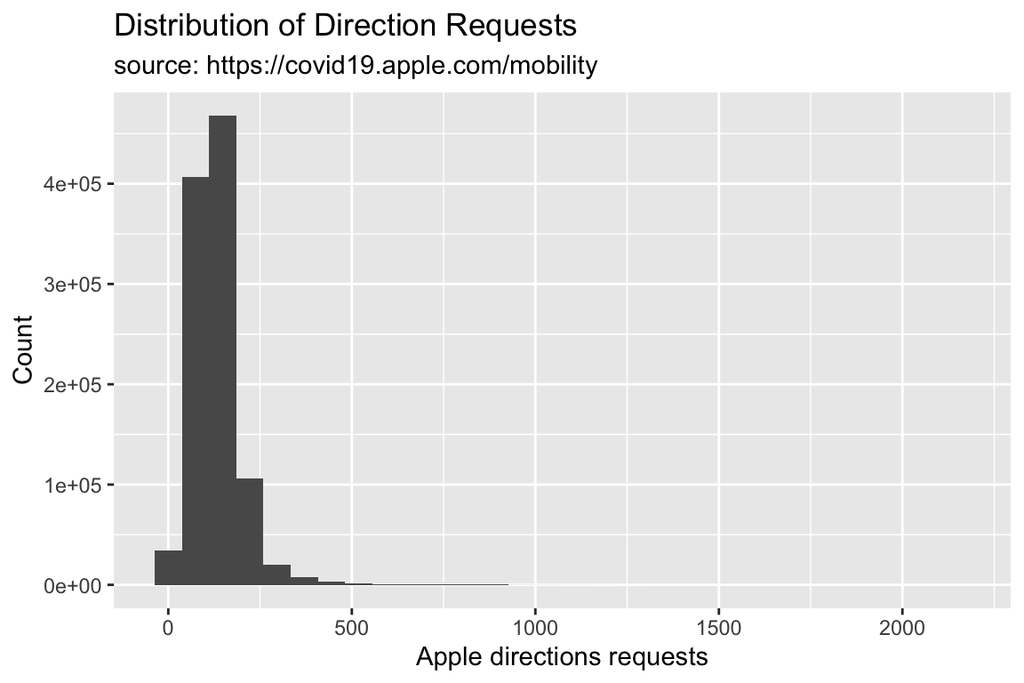

```r
TidyApple %>% ggplot() +
  geom_histogram(aes(x = dir_request)) +
  lab_hist
```

## 7.2 Adjusting Y Axes

We can see the `y` axis of the histogram is in scientific notation. This might be hard for some audiences to interpret, so we will change this to use the whole number with commas with the [`scales` package](https://scales.r-lib.org/).

### 7.2.1 exercise

Add the `scales::comma` value to the `scale_y_continuous()` function.

```r
library(scales)
TidyApple %>% ggplot() +
  geom_histogram(aes(x = dir_request)) +
  scale_y_continuous(labels = __________) +
  lab_hist
```

### 7.2.2 solution

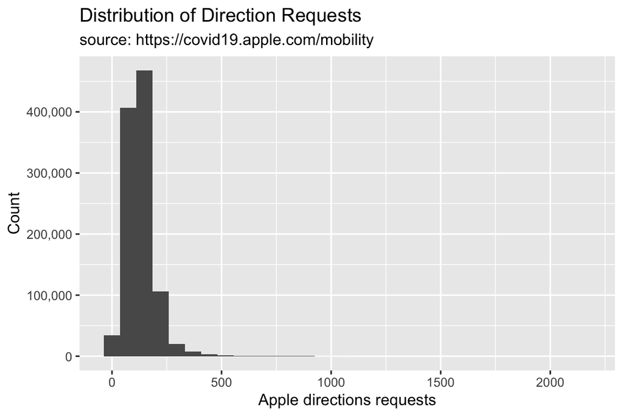

```r
library(scales)
TidyApple %>% ggplot() +
  geom_histogram(aes(x = dir_request)) +
  scale_y_continuous(labels = scales::comma) +
  lab_hist
```

## 7.3 Histogram Shape

We can control the shape of the histogram with the `bins` argument. The default is `30`.

### 7.3.1 exercie

Set `bins` to `15`.

```r
TidyApple %>% ggplot() +
  geom_histogram(aes(x = dir_request), bins = __) +
  scale_y_continuous(labels = scales::comma) +
  lab_hist
```

### 7.3.2 solution

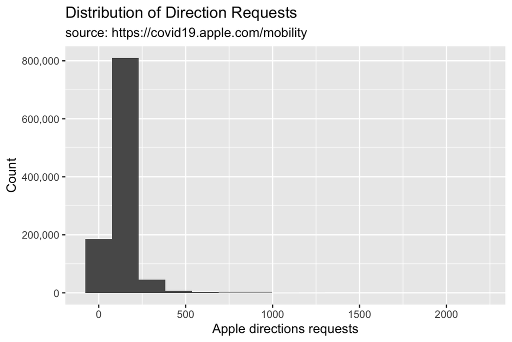

```r
TidyApple %>% ggplot() +
  geom_histogram(aes(x = dir_request), bins = 15) +
  scale_y_continuous(labels = scales::comma) +
  lab_hist
```

### 7.3.3 exercise

Set `bins` to `45` and assign it to `gg_hist45`.

```r
TidyApple %>% ggplot() +
  geom_histogram(aes(x = dir_request), bins = __) +
  scale_y_continuous(labels = scales::comma) +
  lab_hist -> _____________
```

### 7.3.4 solution

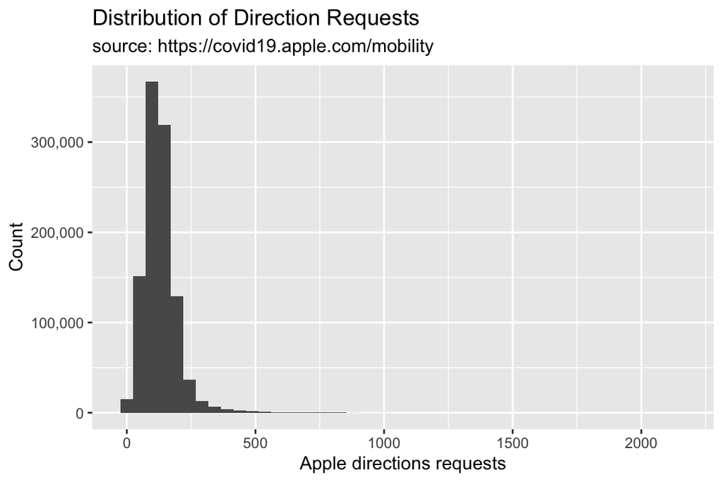

```r
TidyApple %>% ggplot() +
  geom_histogram(aes(x = dir_request), bins = 45) +
  scale_y_continuous(labels = scales::comma) +
  lab_hist -> gg_hist45
```

## 7.4 Density Plots

What if we want to see how a continuous variable is distributed across a categorical variable? We covered this in the [previous lesson with a boxplot](https://mjfrigaard.github.io/data-viz-intro/Index.html#87).

Density plots come in handy here (so do `geom_boxplot()`s!). Read more about the density geom [here](https://ggplot2.tidyverse.org/reference/geom_density.html).

We are going to create the graph labels so we know what to expect when we build our graph, and we want to see the distribution of the directions request, filled by the levels of transportation type.

```r
lab_density <- labs(x = "Apple directions requests",
                    fill = "Transit Type",
     title = "Distribution of Direction Requests vs. Transportation Type",
     subtitle = "source: https://covid19.apple.com/mobility")
```

Now we build the density plot, passing the variables so they match our labels above.

### 7.4.1 exercise

Create a density plot of direction requests colored by the type of transportation.

```r
TidyApple %>%
  ggplot() +
  geom_density(aes(x = __________, fill = __________)) +
  lab_density
```

### 7.4.2 solution

*One drawback to density plots is the `y` axis can be hard to interpret*

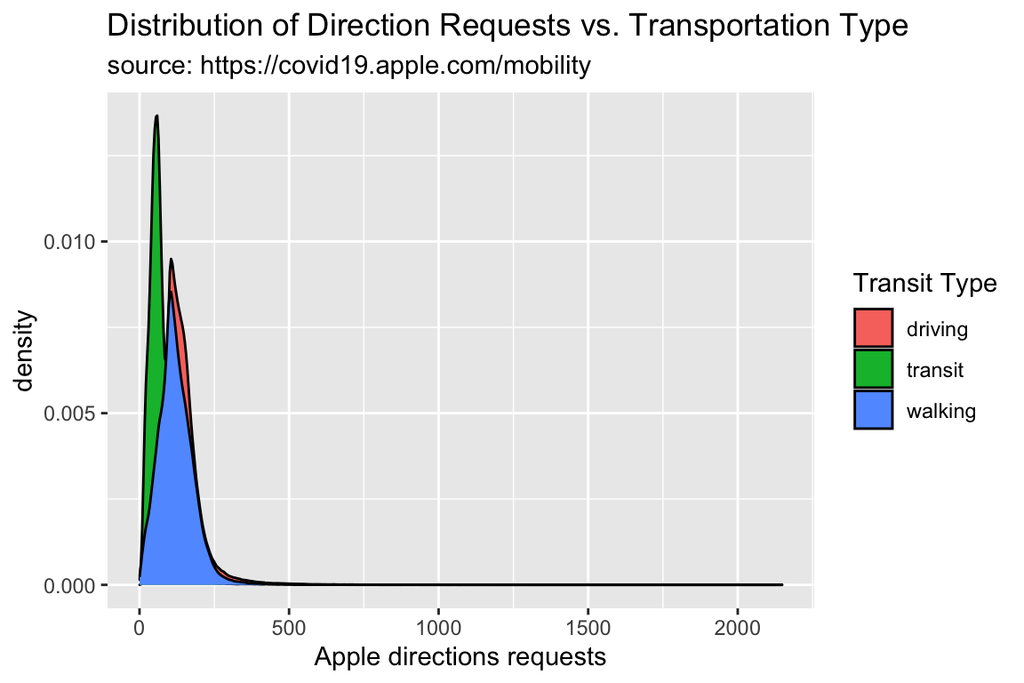

```r
TidyApple %>%
  ggplot() +
  geom_density(aes(x = dir_request, fill = trans_type)) +
  lab_density
```

### 7.4.3 exercise

Adjust the overlapping densities by setting `alpha` to `1/3`. Assign this plot to `gg_density`.

```r
TidyApple %>%
  ggplot() +
  geom_density(aes(x = dir_request, fill = trans_type),
               alpha = __________) +

  lab_density -> __________
```

### 7.4.4 solution

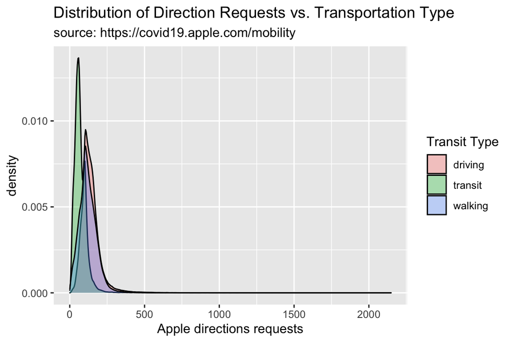

```r
TidyApple %>%
  ggplot() +
  geom_density(aes(x = dir_request, fill = trans_type),
               alpha = 1/3) +
  lab_density -> gg_density

gg_density
```

## 7.5 Ridgeline Plots

Another option is a ridgeline plot (from the `ggridges` package). These display multiple densities.

```r
lab_ridges <- labs(
     title = "Direction Requests by Transportation Type",
     subtitle = "source: https://covid19.apple.com/mobility",
     fill = "Transit type",
     x = "Apple directions requests",
     y = "Transportation Types")
```

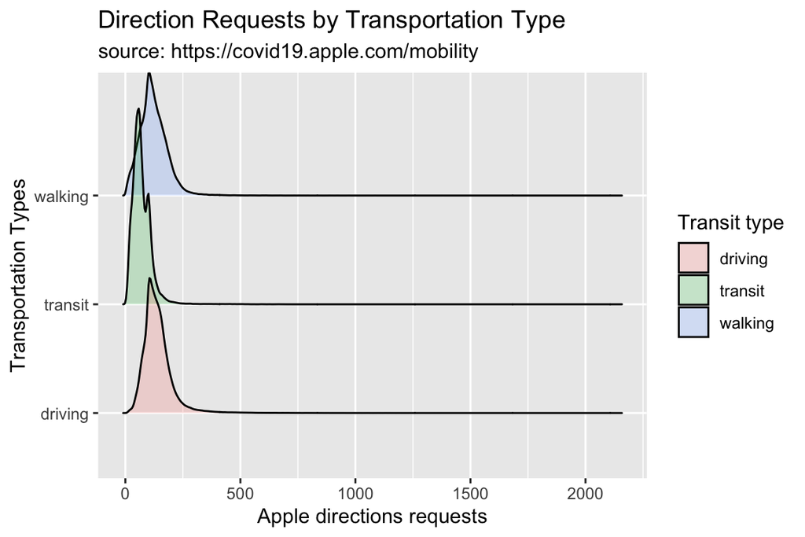

```r
library(ggridges)
TidyApple %>%
  ggplot() +
  geom_density_ridges(aes(x = dir_request,
                          y = trans_type,
                          fill = trans_type),
                      alpha = 1/5) +
  lab_ridges
```

## 7.6 Violin Plots

Another alternative to the density plot is the violin plot.

### 7.6.1 exercise

```r
lab_violin <- labs(x = _________________________,
                    y = _________________________,
                   fill = "Transit Type",
     title = "Distribution of Direction Requests vs. Transportation Type",
     subtitle = "source: https://covid19.apple.com/mobility")
```

### 7.6.2 solution

```r
lab_violin <- labs(x = "Transit Type",
                   y = "Apple directions requests",
                   fill = "Transit Type",
     title = "Distribution of Direction Requests vs. Transportation Type",
     subtitle = "source: https://covid19.apple.com/mobility")
```

### 7.6.3 exercise

Add a `geom_violin()` to the code below:

```r
TidyApple %>%
  ggplot() +
  ____________(aes(y = dir_request, x = trans_type,
                  fill = trans_type)) +
  lab_violin
```

### 7.6.4 solution

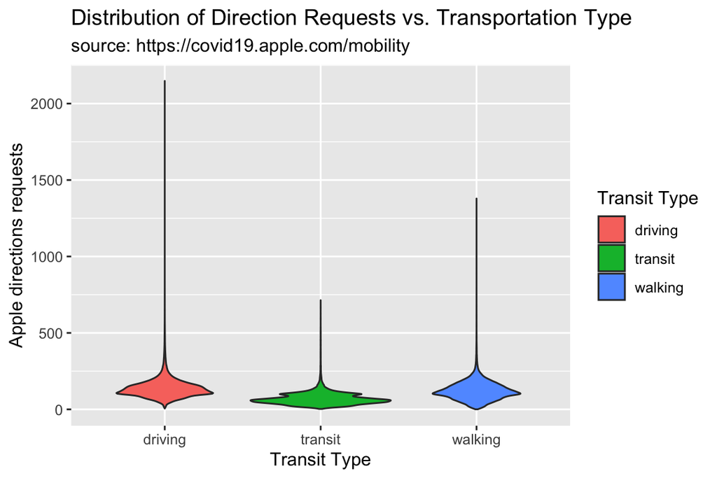

```r
TidyApple %>%
  ggplot() +
  geom_violin(aes(y = dir_request, x = trans_type,
                  fill = trans_type)) +
  lab_violin
```

### 7.6.5 exercise

The great thing about `ggplot2`s layered syntax, is that we can add `geoms` with similar aesthetics to the same graph! For example, we can see how `geom_violin`s and `geom_boxplot`s are related by adding a `geom_boxplot()` layer to the graph above.

```r
TidyApple %>%
  ggplot() +
  geom_violin(aes(y = dir_request, x = trans_type,
                  fill = trans_type), alpha = 1/5) +
  ___________(aes(y = dir_request, x = trans_type,
                   color = trans_type)) +
  lab_violin
```

### 7.6.6 solution

Note we set the `alpha` to `1/5` for the `geom_violin()`, and the `color` to `trans_type` for the `geom_boxplot()`.

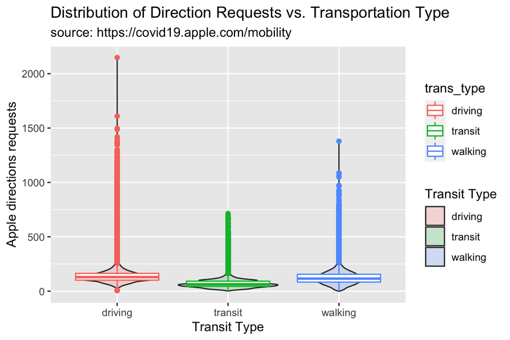

```r
TidyApple %>%
  ggplot() +
  geom_violin(aes(y = dir_request, x = trans_type,
                  fill = trans_type), alpha = 1/5) +
  geom_boxplot(aes(y = dir_request, x = trans_type,
                   color = trans_type)) +
  lab_violin
```

## 7.7 Export the data

You’ll want to export the `TidyApple` dataset for the next set of exercise.

The code chunk below exports the dataset as a .csv.

```r
fs::dir_create("../data/wk5-01-intro-to-ggp2-part-02/")
readr::write_csv(x = TidyApple,
                 file = "../data/wk5-01-intro-to-ggp2-part-02/TidyApple.csv")
```